# Week4_Peer_Graded

Jayant

10/21/2020

This is the week 4 final course project of the practical machine learning also in this I will be using rstudio markdown and knitr. proceeding for the analysis

Introduction of the project

we have collected huge databases from the Nike band, Fitbit, jawbone, and we will be utilizing those data for our analysis in this peer grade assignment.

So in this project, with the data from the accelerometer measure. of the individuals of their different-different class of physical activity

with the help of data, we will be predicting whether the individual is doing the exercises properly or not and the two files comprise of the test and training data, and from this, we will also predict the numbering of exercise like the order of them basically

firstly we will load the data and then proceed for the processing of the data and then we will do the exploratory analysis and then prediction for which model to select and then finally for the predicting of the o/p of the testing set

```r
library(caret)
```

```r
library(knitr)

library(data.table)
library(rpart.plot)
library(rpart)

library(gbm)
library(ggplot2)

library(corrplot)
```

Now we will take the data and do the cleaning and then exploring the data.

```r
testUrl <- "https://d396qusza40orc.cloudfront.net/predmachlearn/pml-testing.csv"
traUrl  <- "https://d396qusza40orc.cloudfront.net/predmachlearn/pml-training.csv"

test_this_data <- read.csv(url(testUrl))
tra_this_data <- read.csv(url(traUrl))
```

now proceeding for the cleaning the input of the data

```r
this_is_training_data <- tra_this_data[, colSums(is.na(tra_this_data)) == 0]
this_is_testing_data <- test_this_data[, colSums(is.na(test_this_data)) == 0]
```

```r
this_is_training_data <- this_is_training_data[, -c(1:7)]
this_is_testing_data <- this_is_testing_data[, -c(1:7)]
dim(this_is_training_data)
```

```
## [1] 19622    86
```

```r
set.seed(1234)
datatraining <- createDataPartition(tra_this_data$classe, p = 0.7, list = FALSE)
this_is_training_data <- this_is_training_data[datatraining, ]
this_is_testing_data <- this_is_training_data[-datatraining, ]
dim(this_is_training_data)
```

```
## [1] 13737    86
```

```r
dim(this_is_testing_data)
```

```
## [1] 4123   86
```

now we will be removing the variables that are non zero from the data gives

```r
noneZero <- nearZeroVar(this_is_training_data)
this_is_training_data <- this_is_training_data[, -noneZero]
this_is_testing_data <- this_is_testing_data[, -noneZero]
dim(this_is_training_data)
```

```
## [1] 13737    53
```

```r
dim(this_is_testing_data)
```

```
## [1] 4123   53
```

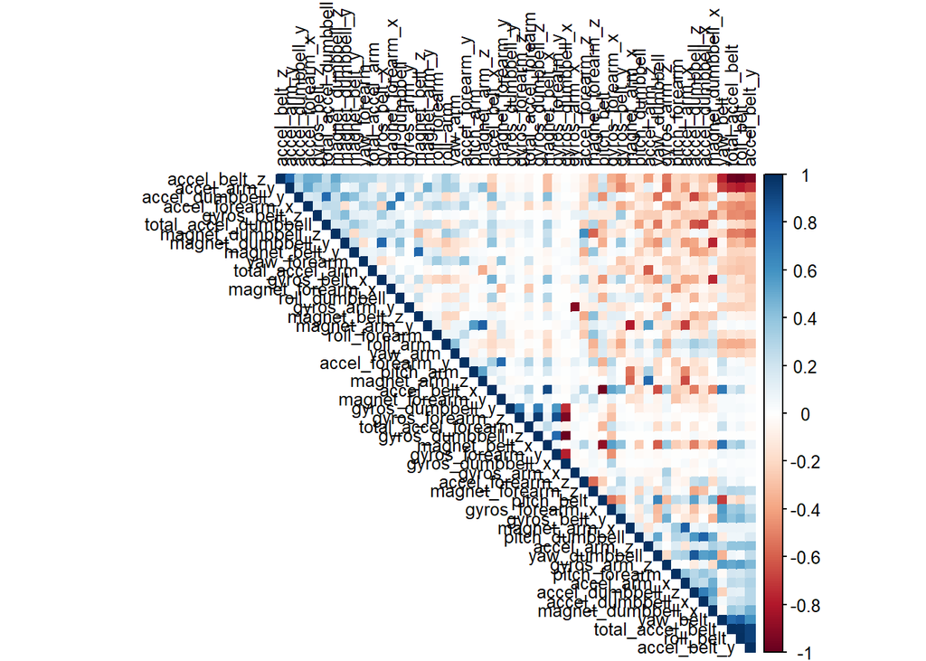

```r
plot_cor <- cor(this_is_training_data[, -53])
corrplot(plot_cor, order = "FPC", method = "color", type = "upper", tl.cex = 0.8, tl.col = rgb(0, 0, 0))
```

now in this as we can see that the corr. predic. are the ones with the dark colour intersec.

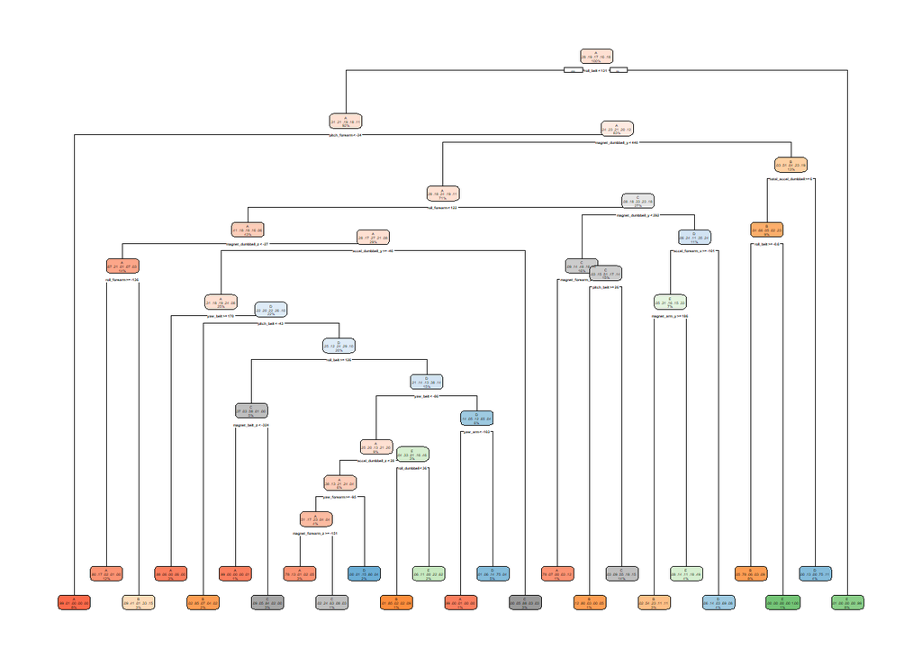

```r
set.seed(20000)
tredec <- rpart(classe ~ ., data=this_is_training_data, method = "class")
rpart.plot(tredec)
```

now we will be validate the model

```r
modelpre <- predict(tredec, this_is_testing_data, type = "class")
ab <- confusionMatrix(modelpre, this_is_testing_data$classe)
ab
```

```
## Confusion Matrix and Statistics
##
##           Reference
## Prediction    A    B    C    D    E
##          A 1067  105    9   24    9
##          B   40  502   59   63   77
##          C   28   90  611  116   86
##          D   11   49   41  423   41
##          E   19   41   18   46  548
##
## Overall Statistics
##
##                Accuracy : 0.7642
##                  95% CI : (0.751, 0.7771)
##     No Information Rate : 0.2826
##     P-Value [Acc > NIR] : < 2.2e-16
##
##                   Kappa : 0.7015
##
##  Mcnemar's Test P-Value : < 2.2e-16
##
## Statistics by Class:
##
##                      Class: A Class: B Class: C Class: D Class: E
## Sensitivity            0.9159   0.6379   0.8279   0.6295   0.7201
## Specificity            0.9503   0.9284   0.9055   0.9589   0.9631
## Pos Pred Value         0.8789   0.6775   0.6563   0.7487   0.8155
## Neg Pred Value         0.9663   0.9157   0.9602   0.9300   0.9383
## Prevalence             0.2826   0.1909   0.1790   0.1630   0.1846
## Detection Rate         0.2588   0.1218   0.1482   0.1026   0.1329
## Detection Prevalence   0.2944   0.1797   0.2258   0.1370   0.1630
## Balanced Accuracy      0.9331   0.7831   0.8667   0.7942   0.8416
```

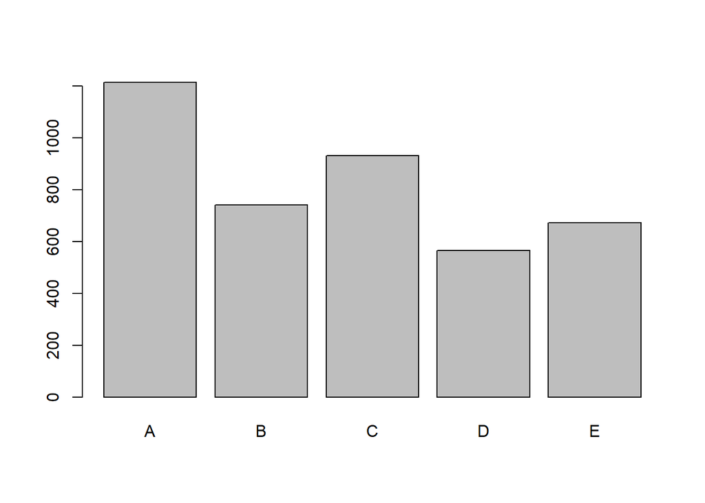

```r
plot(modelpre)
```

```r
set.seed(10000)
ctr_gbm <- trainControl(method = "repeatedcv", number = 5, repeats = 1)
valid_gbm <- train(classe ~ .,data=this_is_training_data, method = "gbm", trControl = ctr_gbm, verbose = FALSE)
valid_gbm$finalModel
```

```
## A gradient boosted model with multinomial loss function.
## 150 iterations were performed.
## There were 52 predictors of which 52 had non-zero influence.
```